# R Notebook

# Momentum Trading

## Data loading

We start by loading the data from our database. We can view the instruments present.

```r
names(mylist)
```

```
 [1] "ABB.ST"     "ALFA.ST"    "AMD"        "AMZN"       "ASSA-B.ST"  "ATCO-A.ST"
 [7] "ATCO-B.ST"  "AZN.ST"     "BOL.ST"     "ELUX-B.ST"  "ERIC-B.ST"  "F"
[13] "FB"         "GETI-B.ST"  "GOOG"       "HM-B.ST"    "HMB.ST"     "IBM"
[19] "INTC"       "INVE-B.ST"  "LUPE.ST"    "MSFT"       "MTG-B.ST"   "NDA-SEK.ST"
[25] "NFLX"       "NVDA"       "SAND.ST"    "SCA-B.ST"   "SCV-B.ST"   "SEB-A.ST"
[31] "SECU-B.ST"  "SHB-A.ST"   "SKA-B.ST"   "SKF-B.ST"   "SSAB-A.ST"  "SWED-A.ST"
[37] "SWMA.ST"    "TEL2-B.ST"  "TELIA.ST"   "TLSN.ST"    "TSLA"       "UG.PA"
[43] "VLKAY"      "VOLV-B.ST"
```

We will only focus on the most interesting ones for now which we’ll define below.

```r
nasdaqSymbols<-c('MSFT', 'IBM', 'FB', 'GOOG', 'AMZN', 'NFLX',
                 'NVDA', 'AMD', 'INTC',
                 'TSLA', 'VLKAY', 'F')
```

We can have a look at how the Microsoft share has done over the years.

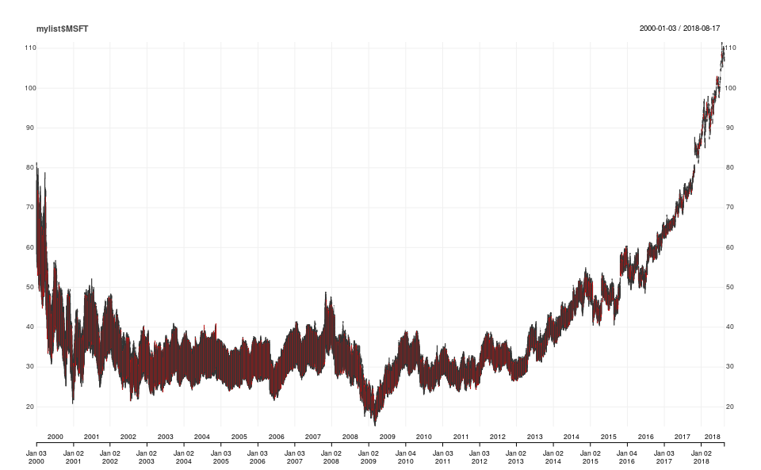

## Trading strategy

We define a trading strategy as a function taking an xts time series featuring OHLC and based on a horizon decide weather to invest or not. The strategy we are concerned with in this notebook is the momentum strategy. It combines momentum together with risk. Basically it invests if

$$\frac{m(x)}{v(x)}>0$$
and holds the position until that condition is no longer true.

```r
momentumStrategy <- function(x, horizon=30){
  xhor <- tail(x, horizon)
  m <- tail(momentum(Cl(xhor), n=horizon-1), 1)[[1]]
  v <- tail(volatility(xhor, n=horizon), 1)[[1]]
  value <- m/v
  # browser()
  if(value > 0) return(list(Invest=TRUE))
  return(list(Invest=FALSE))
}
```

Before moving on we also need to define a function for generating positions based on a strategy. This can be achieved by this code.

```r
# Generate historical positions based on a trading strategy.
generateHistoricalPositions <- function(x, tstrat, h=60) {
  mypos<-rep(0,nrow(x))
  for(i in h:nrow(x)) mypos[i]<-ifelse(tstrat(x[(i-h):i,], h)$Invest==TRUE, 1, 0)
  mypos
}
# How many trades are made in this position vector?
numTrades<-function(p) length(which(abs(diff(p))>0))
```

Armed with this we can actually run through our symbols and apply our strategy. We do that by backtesting against a buy-and-hold strategy.

```r
mytib<-data.frame(Name=as.character(length(nasdaqSymbols)),
                  Trading=as.numeric(length(nasdaqSymbols)),
                  stringsAsFactors = FALSE)
for(i in 1:length(nasdaqSymbols)){
  cost <- 100/7 # 100 DKK in Dollars
  x<-mylist[[nasdaqSymbols[i]]]; h<-90;
  x<-tail(x, 1573)
  mypos<-generateHistoricalPositions(x, momentumStrategy, h)
  a<-dailyReturn(x)*mypos; a[which(a==0)]<-NA; a<-a[!is.na(a)]
  b<-dailyReturn(x)
  mytib[i, "Name"] <- nasdaqSymbols[i]
  mytib[i, "Trading"] <- length(which(a>0))/length(a)
  mytib[i, "Hold"] <- length(which(b>0))/length(b)
  mytib[i, "Trading1000"] <- prod(1+a)*1000 - numTrades(mypos)*cost
  mytib[i, "Hold1000"] <- prod(1+b)*1000 - cost
}
```

```r
mytib %>% mutate(ImprovementIndex=100*round(Trading1000/Hold1000,2))
```

| Name | Trading | Hold | Trading1000 | Hold1000 | ImprovementIndex |
| --- | --- | --- | --- | --- | --- |
| MSFT | 0.5291139 | 0.5149396 | 3856.2551 | 3061.5378 | 126 |
| IBM | 0.5463918 | 0.4958678 | 1020.7640 | 582.3744 | 175 |
| FB | 0.5481781 | 0.5270184 | 7941.2986 | 4118.8891 | 193 |
| GOOG | 0.5340716 | 0.5238398 | 3201.9391 | 3853.1666 | 83 |
| AMZN | 0.5519263 | 0.5378258 | 6482.8468 | 8564.2657 | 76 |
| NFLX | 0.5144270 | 0.5111252 | 51159.8401 | 30654.7044 | 167 |
| NVDA | 0.5500394 | 0.5314685 | 23108.0687 | 17864.9232 | 129 |
| AMD | 0.5578145 | 0.4914177 | 58083.1283 | 3179.5754 | 1827 |
| INTC | 0.5534392 | 0.5232041 | 2451.7441 | 1458.4637 | 168 |
| TSLA | 0.5544554 | 0.5162111 | 22058.1271 | 10754.1316 | 205 |

[output cut: 2 more lines]